# de5f9a90-3493-4fce-a238-efaa8a370306

‌Лабораторная работа 2

Дискреционное разграничение прав в Linux. Основные атрибуты

Скалозуб Александр НПИбд-02-24 1032241329

‌Цель работы

Получение практических навыков работы в консоли с атрибутами файлов, закрепление теоретических основ дискреционного разграничения доступа в современных системах с открытым кодом на базе ОС Linux1 .

‌Рабочая машина

Процессор: ryzen 7 7435hs 3.10 GHz

Оперативная память: DDR5 16x2 4800 mhz

Видеокарта: RTX 4050M 140W 6GB GDDR6

1. ‌рис.

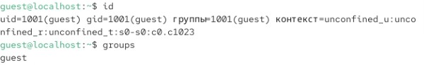

3. рис.

Уточнение имя пользователя, его группа, а также группы, куда входит пользователь и проверка совпадения имен в группе

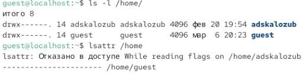

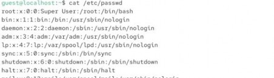

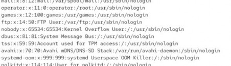

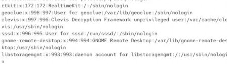

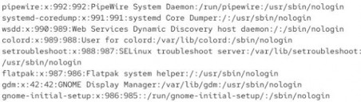

1. ‌рис.

   Проверка существования в системе директории
2. рис.

   Проверка, какие расширенные атрибуты установлены на

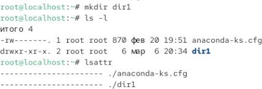

   поддиректориях

   2.0 рис.

   Просмотр файла
3. рис.

Создание дом. Директории и проверка на права доступа и расширенные атрибуты

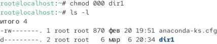

‌3.0 рис.

Снятие всех атрибутов и проверка на успешность

выполнения

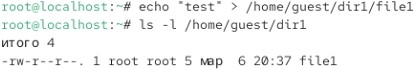

3.1 рис.

Создание директории командами и проверка

нахождения файла в директории

‌Вывод

Получены практические навыки работы в консоли с атрибутами файлов, закрепления теоретических основ дискреционного разграничения доступа в современных системах с открытым кодом на базе ОС Linux1 .